# Taller 1 - Simulación

Diego Andres Riveros Lopez - Juan David Romero Garcia

2022-03-25

### **EJERCICIO 1°**

La tabla mostrada contiene valores de población, en cientos de miles, de las diez ciudades más pobladas de cuatro países en el año 1967:

[output not shown]

**A.** Construya un box-plot e identifique los puntos extremos. ¿Cuáles son las características más sobresalientes? ¿Hay outliers?

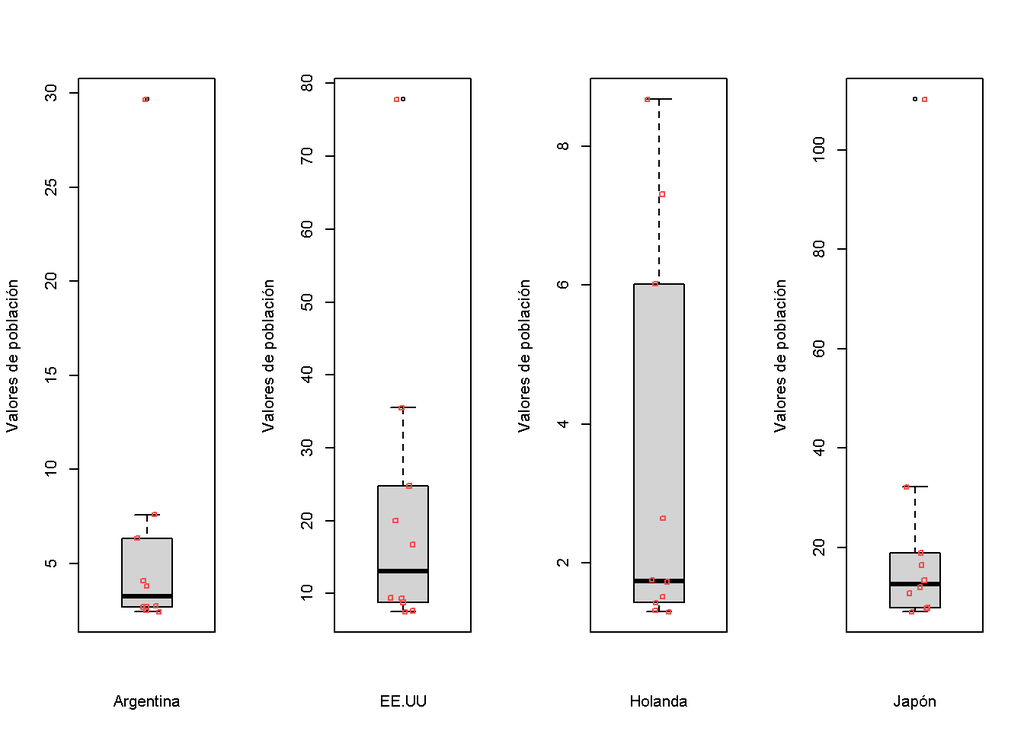

[output not shown]

**B.** Compare los centros de cada población, sus dispersiones y su simetría. ¿Cuál es el país más homogéneamente habitado? ¿Cuáles son las características más sobresalientes? ¿Hay outliers?

```
## [1] "Para las 10 ciudades de Argentina tenemos los valores de la media:  6.461  un valor de desviacion estandar de:  8.3406  y con un coeficiente de simetria de:  2.4567  por ende tiene una simetria positiva."
```

```
## [1] "Para las 10 ciudades de EE.UU tenemos los valores de la media:  21.748  un valor de desviacion estandar de:  21.7217  y con un coeficiente de simetria de:  1.9086  por ende tiene una simetria positiva."
```

```
## [1] "Para las 10 ciudades de Holanda tenemos los valores de la media:  3.365  un valor de desviacion estandar de:  2.8373  y con un coeficiente de simetria de:  0.9735  por ende tiene una simetria positiva."
```

```
## [1] "Para las 10 ciudades de Japón tenemos los valores de la media:  23.611  un valor de desviacion estandar de:  31.3296  y con un coeficiente de simetria de:  2.4078  por ende tiene una simetria positiva."
```

[output not shown]

[output not shown]

### **EJERCICIO 2°**

Avianca se encuentra estudiando la situación de venta de puesto en el vuelo Armenia – Bogotá puesto que ha identificado que el 2% de las personas que reservaron puesto, no se presentan a la hora del embarque. Teniendo en cuenta que el avión A320 utilizado en esta ruta tiene una capacidad para 180 pasajeros, la empresa decide vender 181 tiquetes. ¿Cuál es la probabilidad de que todas las personas que llegan a embarque puedan tener su silla asegurada y no se presenten quejas por “sobre-vender” sillas ante la aeronáutica civil? Asuma que las llegadas de los pasajeros siguen una distribución Poisson.

[output not shown]

[output not shown]

[output not shown]

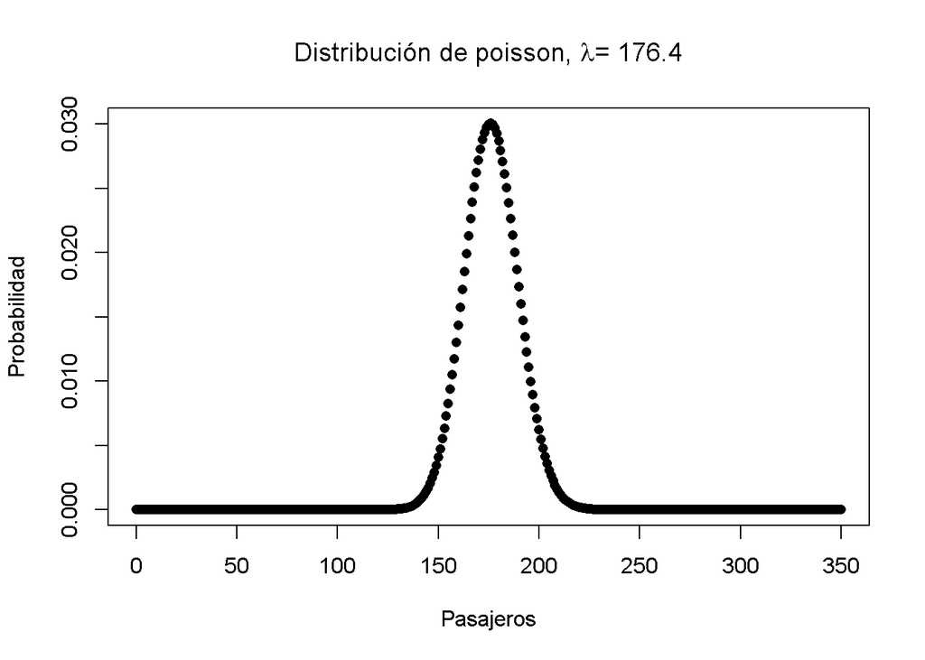

### **EJERCICIO 3°**

En la planta envasadora de Coca-Cola FEMSA ubicada en Tocancipá se realiza el embotellado de la Coca-Cola presentación de 400 mL (en promedio), con una desviación estándar de 5 mL (mililitros). Si se sabe por experiencia que este proceso de embotellado sigue una distribución normal, y también se sabe que todo producto con más de 415 mL es declarado como NO CONFORME. Determine el porcentaje de las botellas de gaseosa que son declaradas producto NO CONFORME.

```
## [1] "Se tiene una media de 400ml y una desviación promedio de 5ml."
```

[output not shown]

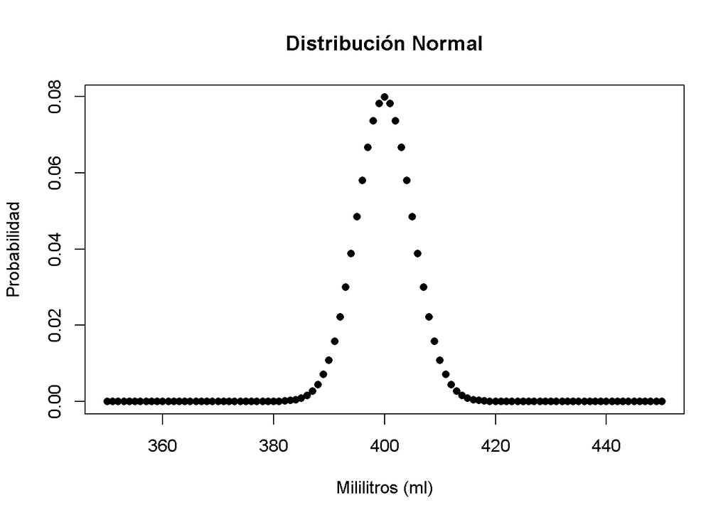